# Modelos individuais - convergência em redes completas

Nesta seção, vamos examinar a convergência do modelo de indivíduos para o compartimental quando o passo temporal vai a zero.

## Cenário com rede completa

Para testar as implementações do modelo de indivíduos, vamos considerar um cenário em que a rede é homogêna, tornando a comparação com o SIR compartimental mais direta.

Neste cenário, desconsideramos as interações aleatórias com a comunidade ($\beta_c=0$) e as interações nas residências ($\beta_r=0$). Completamos fazendo a rede social ser completa (cada indivíduo interage com todos os outros indivíduos, com o mesmo peso) e definindo $\beta_s = \beta$.

No que se segue, vamos comparar as duas implementações (matricial e vetorial) com o SIR, em diversas situações.

### Parâmetros do cenário inicial e da epidemia

```python
num_pop = 60
num_infectados_0 = 6
beta = 0.5
gamma = 0.2

pop_sir_0 = [num_pop-num_infectados_0, num_infectados_0, 0]

rede_completa = episiming.cenarios.RedeCompleta(num_pop, num_infectados_0, beta, gamma)
```

```python
%%time

num_sim = 20
dt_0 = 4 # primeiro passo
J = 8 # número de passos dt
t_0 = 0 # instante initial
T_max = 40 # instante final máximo

l_2_comp_20, l_2_comp_mat, l_infty_comp, l_infty_comp_mat, l_2_dif, l_infty_dif, \
    dt_lista, X_comp, X_comp_mat, X_sir, dt \
    = calcula_convergencia(num_sim, t_0, dt_0, T_max, J)
```

```
8 simulações com dt decrescente:
Valores de dt: [4.0, 2.0, 1.0, 0.5, 0.25, 0.125, 0.0625, 0.03125]

Calculando soluções e diferenças para dt = 4.0...
Norma L^2 entre X_comp.I_medio e X_sir.I: 60.443320080451684
Norma L^2 entre X_comp_mat.I_medio e X_sir.I: 59.248366526950136
Norma L^2 entre X_comp.I_medio e X_comp_mat.I_medio: 15.437616396322328
Norma L^infty entre X_comp.I_medio e X_sir.I: 8.841213823976577
Norma L^infty entre X_comp_mat.I_medio e X_sir.I: 9.09824302972666
Norma L^infty entre X_comp.I_medio e X_comp_mat.I_medio: 1.6499999999999995

Calculando soluções e diferenças para dt = 2.0...
Norma L^2 entre X_comp.I_medio e X_sir.I: 20.34671975354644
Norma L^2 entre X_comp_mat.I_medio e X_sir.I: 21.59119914340751
Norma L^2 entre X_comp.I_medio e X_comp_mat.I_medio: 6.122091146005589
Norma L^infty entre X_comp.I_medio e X_sir.I: 5.248243029726659
Norma L^infty entre X_comp_mat.I_medio e X_sir.I: 4.919102744322473
Norma L^infty entre X_comp.I_medio e X_comp_mat.I_medio: 0.8999999999999995

Calculando soluções e diferenças para dt = 1.0...
Norma L^2 entre X_comp.I_medio e X_sir.I: 7.552629453021987
Norma L^2 entre X_comp_mat.I_medio e X_sir.I: 5.1785074008631025
Norma L^2 entre X_comp.I_medio e X_comp_mat.I_medio: 3.546829570193639
Norma L^infty entre X_comp.I_medio e X_sir.I: 2.511904450797328
Norma L^infty entre X_comp_mat.I_medio e X_sir.I: 2.1261620619870882
Norma L^infty entre X_comp.I_medio e X_comp_mat.I_medio: 1.75

Calculando soluções e diferenças para dt = 0.5...
Norma L^2 entre X_comp.I_medio e X_sir.I: 3.4230967419864884
Norma L^2 entre X_comp_mat.I_medio e X_sir.I: 3.941334427226203
Norma L^2 entre X_comp.I_medio e X_comp_mat.I_medio: 2.9323625287470843
Norma L^infty entre X_comp.I_medio e X_sir.I: 2.0898944237465003
Norma L^infty entre X_comp_mat.I_medio e X_sir.I: 1.6732058514993051
Norma L^infty entre X_comp.I_medio e X_comp_mat.I_medio: 1.5

Calculando soluções e diferenças para dt = 0.25...
Norma L^2 entre X_comp.I_medio e X_sir.I: 2.6243375690412045
Norma L^2 entre X_comp_mat.I_medio e X_sir.I: 1.6036009785697631
Norma L^2 entre X_comp.I_medio e X_comp_mat.I_medio: 3.462545126059731
Norma L^infty entre X_comp.I_medio e X_sir.I: 0.27053011132659915
```

[output cut: 13 more lines]

```
Norma L^2 entre X_comp_mat.I_medio e X_sir.I: 1.4557205742814245
Norma L^2 entre X_comp.I_medio e X_comp_mat.I_medio: 3.2237279468032036
Norma L^infty entre X_comp.I_medio e X_sir.I: 2.749614365328533
Norma L^infty entre X_comp_mat.I_medio e X_sir.I: 1.5322535843630138
Norma L^infty entre X_comp.I_medio e X_comp_mat.I_medio: 5.149999999999999

Calculando soluções e diferenças para dt = 0.03125...
Norma L^2 entre X_comp.I_medio e X_sir.I: 1.704545048858302
Norma L^2 entre X_comp_mat.I_medio e X_sir.I: 1.7623075419120828
Norma L^2 entre X_comp.I_medio e X_comp_mat.I_medio: 1.0458483772158373
Norma L^infty entre X_comp.I_medio e X_sir.I: 0.9632698871271341
Norma L^infty entre X_comp_mat.I_medio e X_sir.I: 1.6517676917884039
Norma L^infty entre X_comp.I_medio e X_comp_mat.I_medio: 1.5500000000000007
CPU times: user 2min 57s, sys: 522 ms, total: 2min 58s
Wall time: 2min 58s
```

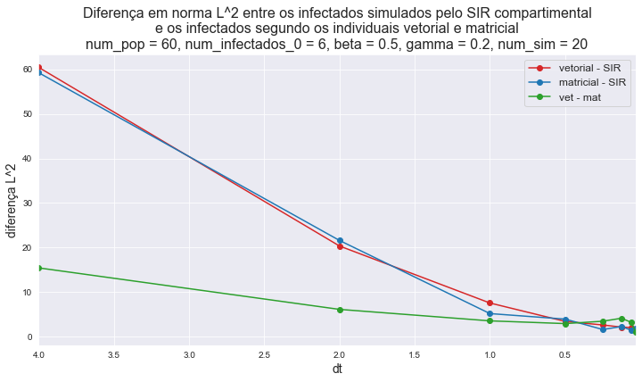

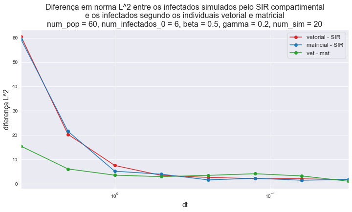

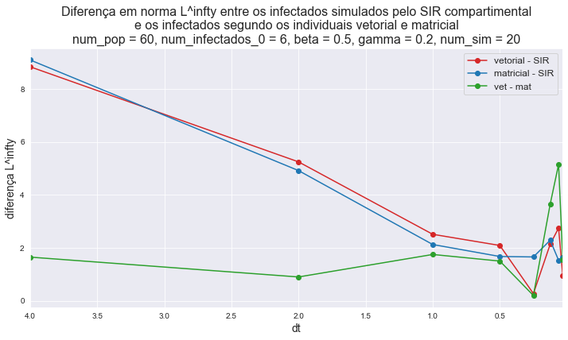

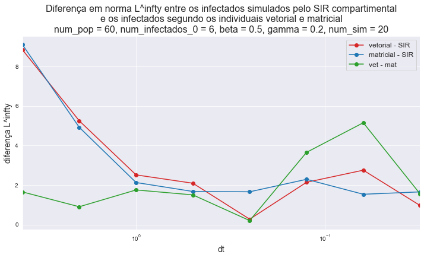

```python
exibe_convergencia(dt_lista, num_pop, num_infectados_0, beta, gamma, num_sim,
                   l_2_comp_20, l_2_comp_mat, l_2_dif, norma = 'L^2', xscale = 'linear')
exibe_convergencia(dt_lista, num_pop, num_infectados_0, beta, gamma, num_sim,
                   l_2_comp_20, l_2_comp_mat, l_2_dif, norma  = 'L^2', xscale = 'log')
exibe_convergencia(dt_lista, num_pop, num_infectados_0, beta, gamma, num_sim,
                   l_infty_comp, l_infty_comp_mat, l_infty_dif, norma  = 'L^infty', xscale = 'linear')
exibe_convergencia(dt_lista, num_pop, num_infectados_0, beta, gamma, num_sim,
                   l_infty_comp, l_infty_comp_mat, l_infty_dif, norma  = 'L^infty', xscale = 'log')
```

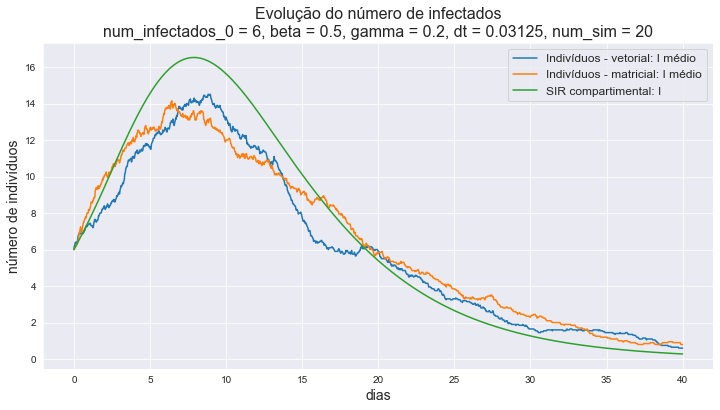

```python
exibe_comparacao(X_comp, X_comp_mat, X_sir, num_infectados_0, beta, gamma, dt, num_sim)
```

## Diminuindo o número de simulações

```python
%%time

num_sim = 5
dt_0 = 4 # primeiro passo
J = 8 # número de passos dt
t_0 = 0 # instante initial
T_max = 40 # instante final máximo

l_2_comp_5, l_2_comp_mat, l_infty_comp, l_infty_comp_mat, l_2_dif, l_infty_dif, \
    dt_lista, X_comp, X_comp_mat, X_sir, dt \
    = calcula_convergencia(num_sim, t_0, dt_0, T_max, J)
```

```
8 simulações com dt decrescente:
Valores de dt: [4.0, 2.0, 1.0, 0.5, 0.25, 0.125, 0.0625, 0.03125]

Calculando soluções e diferenças para dt = 4.0...
Norma L^2 entre X_comp.I_medio e X_sir.I: 57.684835970624796
Norma L^2 entre X_comp_mat.I_medio e X_sir.I: 73.78203439433781
Norma L^2 entre X_comp.I_medio e X_comp_mat.I_medio: 21.850400453996258
Norma L^infty entre X_comp.I_medio e X_sir.I: 9.34824302972666
Norma L^infty entre X_comp_mat.I_medio e X_sir.I: 12.34824302972666
Norma L^infty entre X_comp.I_medio e X_comp_mat.I_medio: 1.5999999999999996

Calculando soluções e diferenças para dt = 2.0...
Norma L^2 entre X_comp.I_medio e X_sir.I: 13.986514301149208
Norma L^2 entre X_comp_mat.I_medio e X_sir.I: 28.396270906066682
Norma L^2 entre X_comp.I_medio e X_comp_mat.I_medio: 18.378248012256233
Norma L^infty entre X_comp.I_medio e X_sir.I: 3.5912138239765756
Norma L^infty entre X_comp_mat.I_medio e X_sir.I: 7.331355032428693
Norma L^infty entre X_comp.I_medio e X_comp_mat.I_medio: 3.799999999999999

Calculando soluções e diferenças para dt = 1.0...
Norma L^2 entre X_comp.I_medio e X_sir.I: 7.843089316622206
Norma L^2 entre X_comp_mat.I_medio e X_sir.I: 15.029751447932444
Norma L^2 entre X_comp.I_medio e X_comp_mat.I_medio: 15.858120947955971
Norma L^infty entre X_comp.I_medio e X_sir.I: 3.3160840673898893
Norma L^infty entre X_comp_mat.I_medio e X_sir.I: 5.129719790898466
Norma L^infty entre X_comp.I_medio e X_comp_mat.I_medio: 5.0

Calculando soluções e diferenças para dt = 0.5...
Norma L^2 entre X_comp.I_medio e X_sir.I: 8.288955954345665
Norma L^2 entre X_comp_mat.I_medio e X_sir.I: 8.352743412644509
Norma L^2 entre X_comp.I_medio e X_comp_mat.I_medio: 15.102648774304459
Norma L^infty entre X_comp.I_medio e X_sir.I: 4.748243029726659
Norma L^infty entre X_comp_mat.I_medio e X_sir.I: 3.0334461743849834
Norma L^infty entre X_comp.I_medio e X_comp_mat.I_medio: 8.399999999999999

Calculando soluções e diferenças para dt = 0.25...
Norma L^2 entre X_comp.I_medio e X_sir.I: 5.38432782967192
Norma L^2 entre X_comp_mat.I_medio e X_sir.I: 2.513669053897834
Norma L^2 entre X_comp.I_medio e X_comp_mat.I_medio: 6.162994402074369
Norma L^infty entre X_comp.I_medio e X_sir.I: 4.172592859882101
```

[output cut: 13 more lines]

```
Norma L^2 entre X_comp_mat.I_medio e X_sir.I: 2.608534146774589
Norma L^2 entre X_comp.I_medio e X_comp_mat.I_medio: 2.78990927271838
Norma L^infty entre X_comp.I_medio e X_sir.I: 1.68504594908282
Norma L^infty entre X_comp_mat.I_medio e X_sir.I: 2.600436213986214
Norma L^infty entre X_comp.I_medio e X_comp_mat.I_medio: 3.3999999999999995

Calculando soluções e diferenças para dt = 0.03125...
Norma L^2 entre X_comp.I_medio e X_sir.I: 1.8586537314225722
Norma L^2 entre X_comp_mat.I_medio e X_sir.I: 1.1290741422620034
Norma L^2 entre X_comp.I_medio e X_comp_mat.I_medio: 2.419654223747682
Norma L^infty entre X_comp.I_medio e X_sir.I: 4.999081774049685
Norma L^infty entre X_comp_mat.I_medio e X_sir.I: 1.5735515054904816
Norma L^infty entre X_comp.I_medio e X_comp_mat.I_medio: 6.600000000000001
CPU times: user 46.8 s, sys: 199 ms, total: 47 s
Wall time: 47 s
```

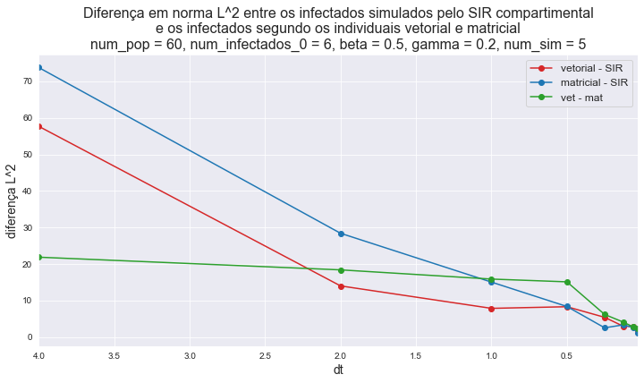

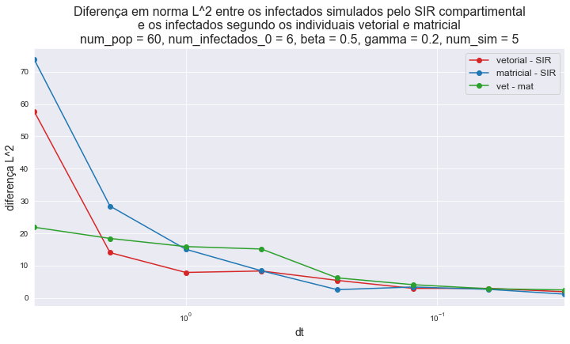

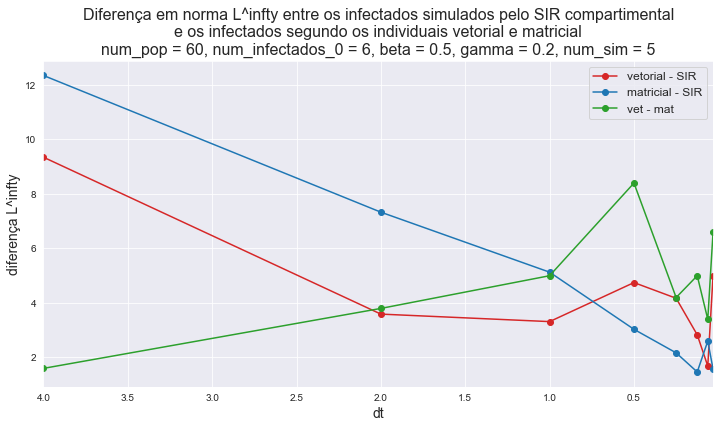

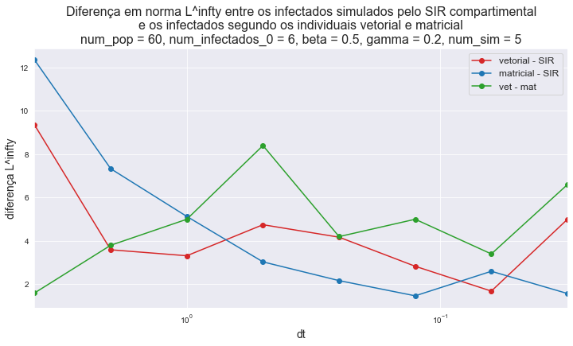

```python
exibe_convergencia(dt_lista, num_pop, num_infectados_0, beta, gamma, num_sim,
                   l_2_comp_5, l_2_comp_mat, l_2_dif, norma = 'L^2', xscale = 'linear')
exibe_convergencia(dt_lista, num_pop, num_infectados_0, beta, gamma, num_sim,
                   l_2_comp_5, l_2_comp_mat, l_2_dif, norma  = 'L^2', xscale = 'log')
exibe_convergencia(dt_lista, num_pop, num_infectados_0, beta, gamma, num_sim,
                   l_infty_comp, l_infty_comp_mat, l_infty_dif, norma  = 'L^infty', xscale = 'linear')
exibe_convergencia(dt_lista, num_pop, num_infectados_0, beta, gamma, num_sim,
                   l_infty_comp, l_infty_comp_mat, l_infty_dif, norma  = 'L^infty', xscale = 'log')
```

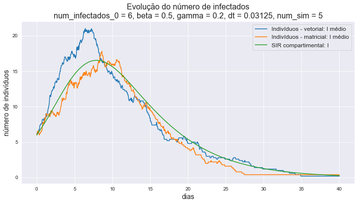

```python
exibe_comparacao(X_comp, X_comp_mat, X_sir, num_infectados_0, beta, gamma, dt, num_sim)
```

## Aumentando o número de simulações

```python
%%time

num_sim = 40
dt_0 = 4 # primeiro passo
J = 8 # número de passos dt
t_0 = 0 # instante initial
T_max = 40 # instante final máximo

l_2_comp_40, l_2_comp_mat, l_infty_comp, l_infty_comp_mat, l_2_dif, l_infty_dif, \
    dt_lista, X_comp, X_comp_mat, X_sir, dt \
    = calcula_convergencia(num_sim, t_0, dt_0, T_max, J)
```

```
8 simulações com dt decrescente:
Valores de dt: [4.0, 2.0, 1.0, 0.5, 0.25, 0.125, 0.0625, 0.03125]

Calculando soluções e diferenças para dt = 4.0...
Norma L^2 entre X_comp.I_medio e X_sir.I: 66.32183577790161
Norma L^2 entre X_comp_mat.I_medio e X_sir.I: 57.77121664427191
Norma L^2 entre X_comp.I_medio e X_comp_mat.I_medio: 15.91665794066079
Norma L^infty entre X_comp.I_medio e X_sir.I: 10.648243029726661
Norma L^infty entre X_comp_mat.I_medio e X_sir.I: 8.266213823976575
Norma L^infty entre X_comp.I_medio e X_comp_mat.I_medio: 2.5

Calculando soluções e diferenças para dt = 2.0...
Norma L^2 entre X_comp.I_medio e X_sir.I: 22.390908613335238
Norma L^2 entre X_comp_mat.I_medio e X_sir.I: 23.73799243139674
Norma L^2 entre X_comp.I_medio e X_comp_mat.I_medio: 5.0867474873439535
Norma L^infty entre X_comp.I_medio e X_sir.I: 5.198243029726662
Norma L^infty entre X_comp_mat.I_medio e X_sir.I: 5.148243029726661
Norma L^infty entre X_comp.I_medio e X_comp_mat.I_medio: 1.1750000000000007

Calculando soluções e diferenças para dt = 1.0...
Norma L^2 entre X_comp.I_medio e X_sir.I: 8.41467499988948
Norma L^2 entre X_comp_mat.I_medio e X_sir.I: 6.4868647465102205
Norma L^2 entre X_comp.I_medio e X_comp_mat.I_medio: 3.5957440120231023
Norma L^infty entre X_comp.I_medio e X_sir.I: 2.616213823976576
Norma L^infty entre X_comp_mat.I_medio e X_sir.I: 1.8725462977656653
Norma L^infty entre X_comp.I_medio e X_comp_mat.I_medio: 1.049999999999999

Calculando soluções e diferenças para dt = 0.5...
Norma L^2 entre X_comp.I_medio e X_sir.I: 2.8632087313954626
Norma L^2 entre X_comp_mat.I_medio e X_sir.I: 2.6171360489737245
Norma L^2 entre X_comp.I_medio e X_comp_mat.I_medio: 3.0951827490473
Norma L^infty entre X_comp.I_medio e X_sir.I: 1.0481518043370466
Norma L^infty entre X_comp_mat.I_medio e X_sir.I: 1.3232058514993055
Norma L^infty entre X_comp.I_medio e X_comp_mat.I_medio: 0.875

Calculando soluções e diferenças para dt = 0.25...
Norma L^2 entre X_comp.I_medio e X_sir.I: 0.9909895755723686
Norma L^2 entre X_comp_mat.I_medio e X_sir.I: 1.976489955520046
Norma L^2 entre X_comp.I_medio e X_comp_mat.I_medio: 1.8733325919334238
Norma L^infty entre X_comp.I_medio e X_sir.I: 0.7422904290739787
```

[output cut: 13 more lines]

```
Norma L^2 entre X_comp_mat.I_medio e X_sir.I: 1.3631385085836207
Norma L^2 entre X_comp.I_medio e X_comp_mat.I_medio: 1.8815802502899657
Norma L^infty entre X_comp.I_medio e X_sir.I: 0.7655460059696328
Norma L^infty entre X_comp_mat.I_medio e X_sir.I: 1.5919016863542268
Norma L^infty entre X_comp.I_medio e X_comp_mat.I_medio: 2.0250000000000004

Calculando soluções e diferenças para dt = 0.03125...
Norma L^2 entre X_comp.I_medio e X_sir.I: 0.8658092302155667
Norma L^2 entre X_comp_mat.I_medio e X_sir.I: 0.6835507744251691
Norma L^2 entre X_comp.I_medio e X_comp_mat.I_medio: 1.1853308210256905
Norma L^infty entre X_comp.I_medio e X_sir.I: 1.6419016863542257
Norma L^infty entre X_comp_mat.I_medio e X_sir.I: 0.804139541679822
Norma L^infty entre X_comp.I_medio e X_comp_mat.I_medio: 2.5
CPU times: user 6min 4s, sys: 1.01 s, total: 6min 5s
Wall time: 6min 5s
```

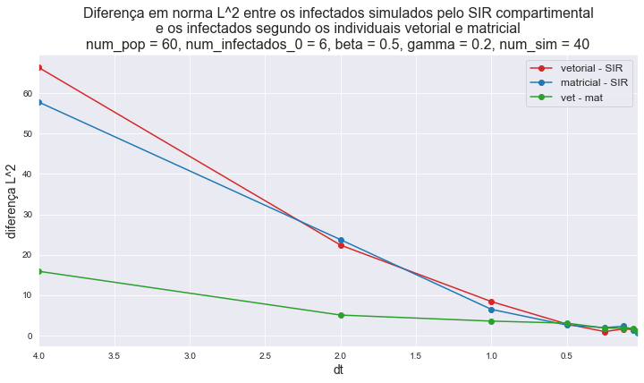

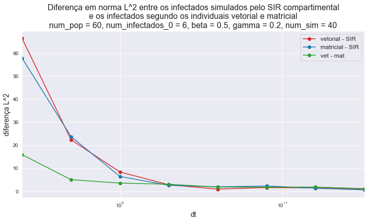

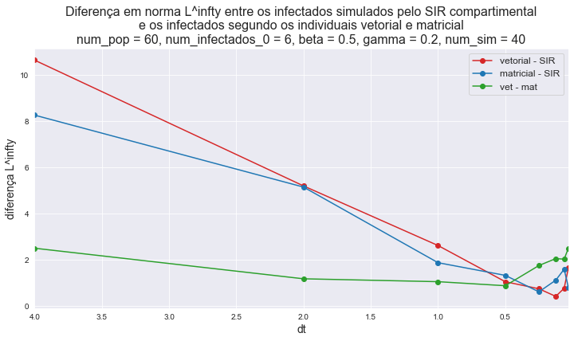

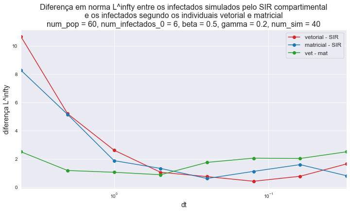

```python
exibe_convergencia(dt_lista, num_pop, num_infectados_0, beta, gamma, num_sim,
                   l_2_comp_40, l_2_comp_mat, l_2_dif, norma = 'L^2', xscale = 'linear')
exibe_convergencia(dt_lista, num_pop, num_infectados_0, beta, gamma, num_sim,
                   l_2_comp_40, l_2_comp_mat, l_2_dif, norma  = 'L^2', xscale = 'log')
exibe_convergencia(dt_lista, num_pop, num_infectados_0, beta, gamma, num_sim,
                   l_infty_comp, l_infty_comp_mat, l_infty_dif, norma  = 'L^infty', xscale = 'linear')
exibe_convergencia(dt_lista, num_pop, num_infectados_0, beta, gamma, num_sim,
                   l_infty_comp, l_infty_comp_mat, l_infty_dif, norma  = 'L^infty', xscale = 'log')
```

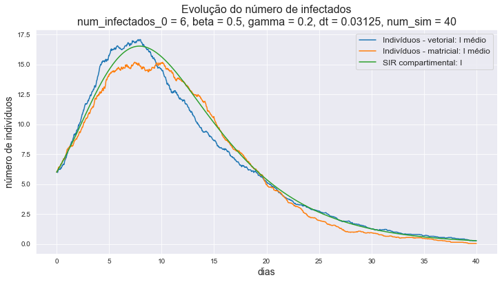

```python
exibe_comparacao(X_comp, X_comp_mat, X_sir, num_infectados_0, beta, gamma, dt, num_sim)
```

### Comparação em relação à variação no número de simulações

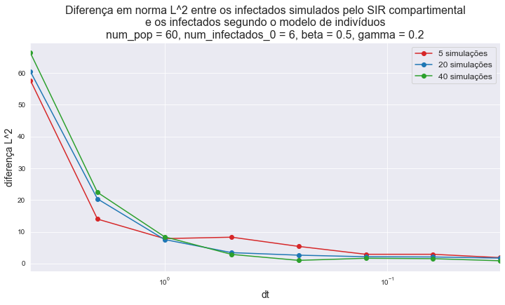

```python
plt.figure(figsize=(12,6))

plt.plot(dt_lista, l_2_comp_5, 'o-', color='tab:red', label='5 simulações')
plt.plot(dt_lista, l_2_comp_20, 'o-', color='tab:blue', label='20 simulações')
plt.plot(dt_lista, l_2_comp_40, 'o-', color='tab:green', label='40 simulações')

plt.xscale('log')
plt.xlim([dt_lista[0], dt_lista[-1]])
plt.legend(loc='best', fontsize=12)

plt.xlabel('dt', fontsize=14)
plt.ylabel(f'diferença L^2', fontsize=14)
plt.title(f'Diferença em norma L^2 entre os infectados simulados pelo SIR compartimental'
          + '\ne os infectados segundo o modelo de indivíduos'
          + f'\nnum_pop = {num_pop}, num_infectados_0 = {num_infectados_0}, beta = {beta}, '
          + f'gamma = {gamma}',
          fontsize = 16)

plt.show()
```

## Aumentando a população

```python
num_pop = 100
num_infectados_0 = 10
beta = 0.5
gamma = 0.2

pop_sir_0 = [num_pop-num_infectados_0, num_infectados_0, 0]

rede_completa = episiming.cenarios.RedeCompleta(num_pop, num_infectados_0, beta, gamma)
```

```python
%%time

num_sim = 20
dt_0 = 4 # primeiro passo
J = 8 # número de passos dt
t_0 = 0 # instante initial
T_max = 40 # instante final máximo

l_2_comp, l_2_comp_mat, l_infty_comp, l_infty_comp_mat, l_2_dif, l_infty_dif, \
    dt_lista, X_comp, X_comp_mat, X_sir, dt \
    = calcula_convergencia(num_sim, t_0, dt_0, T_max, J)
```

```
8 simulações com dt decrescente:
Valores de dt: [4.0, 2.0, 1.0, 0.5, 0.25, 0.125, 0.0625, 0.03125]

Calculando soluções e diferenças para dt = 4.0...
Norma L^2 entre X_comp.I_medio e X_sir.I: 108.57048986492967
Norma L^2 entre X_comp_mat.I_medio e X_sir.I: 102.51242108636268
Norma L^2 entre X_comp.I_medio e X_comp_mat.I_medio: 16.349923547221866
Norma L^infty entre X_comp.I_medio e X_sir.I: 17.297072341392514
Norma L^infty entre X_comp_mat.I_medio e X_sir.I: 15.535341555902273
Norma L^infty entre X_comp.I_medio e X_comp_mat.I_medio: 2.5

Calculando soluções e diferenças para dt = 2.0...
Norma L^2 entre X_comp.I_medio e X_sir.I: 35.306299917498315
Norma L^2 entre X_comp_mat.I_medio e X_sir.I: 44.653028195991105
Norma L^2 entre X_comp.I_medio e X_comp_mat.I_medio: 11.332254850646452
Norma L^infty entre X_comp.I_medio e X_sir.I: 8.347072341392519
Norma L^infty entre X_comp_mat.I_medio e X_sir.I: 10.34850474016968
Norma L^infty entre X_comp.I_medio e X_comp_mat.I_medio: 0.10000000000000053

Calculando soluções e diferenças para dt = 1.0...
Norma L^2 entre X_comp.I_medio e X_sir.I: 8.265600319657212
Norma L^2 entre X_comp_mat.I_medio e X_sir.I: 10.711049076191252
Norma L^2 entre X_comp.I_medio e X_comp_mat.I_medio: 6.68917035214383
Norma L^infty entre X_comp.I_medio e X_sir.I: 2.9947356779225096
Norma L^infty entre X_comp_mat.I_medio e X_sir.I: 3.8122357146425045
Norma L^infty entre X_comp.I_medio e X_comp_mat.I_medio: 1.0999999999999979

Calculando soluções e diferenças para dt = 0.5...
Norma L^2 entre X_comp.I_medio e X_sir.I: 5.3609774306263445
Norma L^2 entre X_comp_mat.I_medio e X_sir.I: 4.823524800302584
Norma L^2 entre X_comp.I_medio e X_comp_mat.I_medio: 8.746749396204285
Norma L^infty entre X_comp.I_medio e X_sir.I: 2.911545813894298
Norma L^infty entre X_comp_mat.I_medio e X_sir.I: 0.8838234848181248
Norma L^infty entre X_comp.I_medio e X_comp_mat.I_medio: 4.25

Calculando soluções e diferenças para dt = 0.25...
Norma L^2 entre X_comp.I_medio e X_sir.I: 2.557768383154575
Norma L^2 entre X_comp_mat.I_medio e X_sir.I: 5.440780712227949
Norma L^2 entre X_comp.I_medio e X_comp_mat.I_medio: 7.098470345785773
Norma L^infty entre X_comp.I_medio e X_sir.I: 1.4278244229553145
```

[output cut: 13 more lines]

```
Norma L^2 entre X_comp_mat.I_medio e X_sir.I: 2.152550436113266
Norma L^2 entre X_comp.I_medio e X_comp_mat.I_medio: 2.9904470297097725
Norma L^infty entre X_comp.I_medio e X_sir.I: 2.665319441829862
Norma L^infty entre X_comp_mat.I_medio e X_sir.I: 1.1977617119440518
Norma L^infty entre X_comp.I_medio e X_comp_mat.I_medio: 4.0

Calculando soluções e diferenças para dt = 0.03125...
Norma L^2 entre X_comp.I_medio e X_sir.I: 0.6238834665662589
Norma L^2 entre X_comp_mat.I_medio e X_sir.I: 0.9792944979549468
Norma L^2 entre X_comp.I_medio e X_comp_mat.I_medio: 1.1128686187057302
Norma L^infty entre X_comp.I_medio e X_sir.I: 0.895884463957767
Norma L^infty entre X_comp_mat.I_medio e X_sir.I: 0.6682486256845781
Norma L^infty entre X_comp.I_medio e X_comp_mat.I_medio: 2.8000000000000007
CPU times: user 6min 17s, sys: 896 ms, total: 6min 18s
Wall time: 6min 18s
```

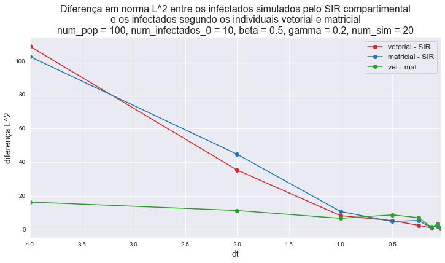

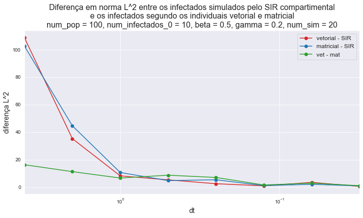

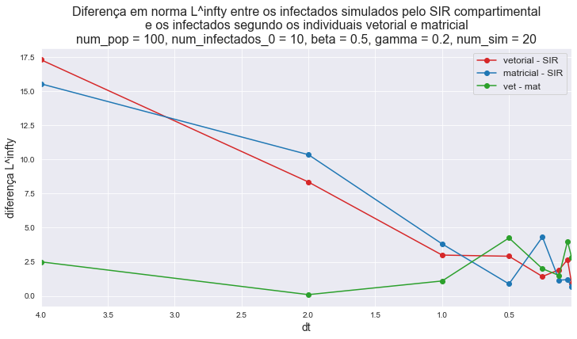

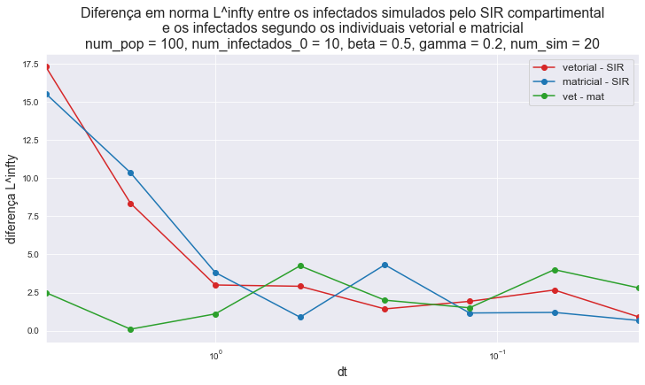

```python
exibe_convergencia(dt_lista, num_pop, num_infectados_0, beta, gamma, num_sim,
                   l_2_comp, l_2_comp_mat, l_2_dif, norma = 'L^2', xscale = 'linear')
exibe_convergencia(dt_lista, num_pop, num_infectados_0, beta, gamma, num_sim,
                   l_2_comp, l_2_comp_mat, l_2_dif, norma  = 'L^2', xscale = 'log')
exibe_convergencia(dt_lista, num_pop, num_infectados_0, beta, gamma, num_sim,
                   l_infty_comp, l_infty_comp_mat, l_infty_dif, norma  = 'L^infty', xscale = 'linear')
exibe_convergencia(dt_lista, num_pop, num_infectados_0, beta, gamma, num_sim,
                   l_infty_comp, l_infty_comp_mat, l_infty_dif, norma  = 'L^infty', xscale = 'log')
```

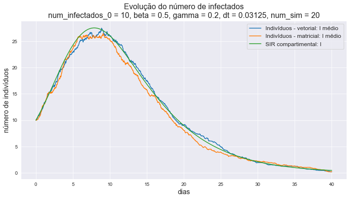

```python
exibe_comparacao(X_comp, X_comp_mat, X_sir, num_infectados_0, beta, gamma, dt, num_sim)
```

## Reduzindo o número de infectados iniciais

```python
num_pop = 100
num_infectados_0 = 4
beta = 0.5
gamma = 0.2

pop_sir_0 = [num_pop-num_infectados_0, num_infectados_0, 0]

rede_completa = episiming.cenarios.RedeCompleta(num_pop, num_infectados_0, beta, gamma)
```

```python
%%time

num_sim = 20
dt_0 = 4 # primeiro passo
J = 7 # número de passos dt
t_0 = 0 # instante initial
T_max = 40 # instante final máximo

l_2_comp, l_2_comp_mat, l_infty_comp, l_infty_comp_mat, l_2_dif, l_infty_dif, \
    dt_lista, X_comp, X_comp_mat, X_sir, dt \
    = calcula_convergencia(num_sim, t_0, dt_0, T_max, J)
```

```
7 simulações com dt decrescente:
Valores de dt: [4.0, 2.0, 1.0, 0.5, 0.25, 0.125, 0.0625]

Calculando soluções e diferenças para dt = 4.0...
Norma L^2 entre X_comp.I_medio e X_sir.I: 109.4608228600231
Norma L^2 entre X_comp_mat.I_medio e X_sir.I: 112.77184320706617
Norma L^2 entre X_comp.I_medio e X_comp_mat.I_medio: 9.604165762834386
Norma L^infty entre X_comp.I_medio e X_sir.I: 16.34759239303324
Norma L^infty entre X_comp_mat.I_medio e X_sir.I: 17.29759239303324
Norma L^infty entre X_comp.I_medio e X_comp_mat.I_medio: 0.75

Calculando soluções e diferenças para dt = 2.0...
Norma L^2 entre X_comp.I_medio e X_sir.I: 37.22939614320178
Norma L^2 entre X_comp_mat.I_medio e X_sir.I: 40.496683929023014
Norma L^2 entre X_comp.I_medio e X_comp_mat.I_medio: 13.446932735757995
Norma L^infty entre X_comp.I_medio e X_sir.I: 8.320393614239077
Norma L^infty entre X_comp_mat.I_medio e X_sir.I: 9.520393614239076
Norma L^infty entre X_comp.I_medio e X_comp_mat.I_medio: 1.0999999999999979

Calculando soluções e diferenças para dt = 1.0...
Norma L^2 entre X_comp.I_medio e X_sir.I: 8.327799553039865
Norma L^2 entre X_comp_mat.I_medio e X_sir.I: 12.877706540980911
Norma L^2 entre X_comp.I_medio e X_comp_mat.I_medio: 11.747020898934334
Norma L^infty entre X_comp.I_medio e X_sir.I: 2.9824818552644317
Norma L^infty entre X_comp_mat.I_medio e X_sir.I: 3.862760991499215
Norma L^infty entre X_comp.I_medio e X_comp_mat.I_medio: 4.350000000000001

Calculando soluções e diferenças para dt = 0.5...
Norma L^2 entre X_comp.I_medio e X_sir.I: 4.046691249626572
Norma L^2 entre X_comp_mat.I_medio e X_sir.I: 14.280314027684952
Norma L^2 entre X_comp.I_medio e X_comp_mat.I_medio: 13.461426373159718
Norma L^infty entre X_comp.I_medio e X_sir.I: 2.1998805651339417
Norma L^infty entre X_comp_mat.I_medio e X_sir.I: 2.2666820874850644
Norma L^infty entre X_comp.I_medio e X_comp_mat.I_medio: 6.399999999999999

Calculando soluções e diferenças para dt = 0.25...
Norma L^2 entre X_comp.I_medio e X_sir.I: 6.066637763942283
Norma L^2 entre X_comp_mat.I_medio e X_sir.I: 2.595981207802337
Norma L^2 entre X_comp.I_medio e X_comp_mat.I_medio: 8.034982109500929
Norma L^infty entre X_comp.I_medio e X_sir.I: 2.40938431225438
Norma L^infty entre X_comp_mat.I_medio e X_sir.I: 1.84920920778681
Norma L^infty entre X_comp.I_medio e X_comp_mat.I_medio: 3.4000000000000004

Calculando soluções e diferenças para dt = 0.125...
Norma L^2 entre X_comp.I_medio e X_sir.I: 2.687808480702512
Norma L^2 entre X_comp_mat.I_medio e X_sir.I: 4.622381040385184
Norma L^2 entre X_comp.I_medio e X_comp_mat.I_medio: 5.724901063555596
Norma L^infty entre X_comp.I_medio e X_sir.I: 4.146570442137715
Norma L^infty entre X_comp_mat.I_medio e X_sir.I: 0.5170408435856744
Norma L^infty entre X_comp.I_medio e X_comp_mat.I_medio: 6.0

Calculando soluções e diferenças para dt = 0.0625...
Norma L^2 entre X_comp.I_medio e X_sir.I: 4.949356925895976
Norma L^2 entre X_comp_mat.I_medio e X_sir.I: 3.7764507109460608
Norma L^2 entre X_comp.I_medio e X_comp_mat.I_medio: 2.152798414999649
Norma L^infty entre X_comp.I_medio e X_sir.I: 2.729347096073557
Norma L^infty entre X_comp_mat.I_medio e X_sir.I: 2.3898428933376845
Norma L^infty entre X_comp.I_medio e X_comp_mat.I_medio: 2.9999999999999982
CPU times: user 3min 14s, sys: 744 ms, total: 3min 15s
Wall time: 3min 15s
```

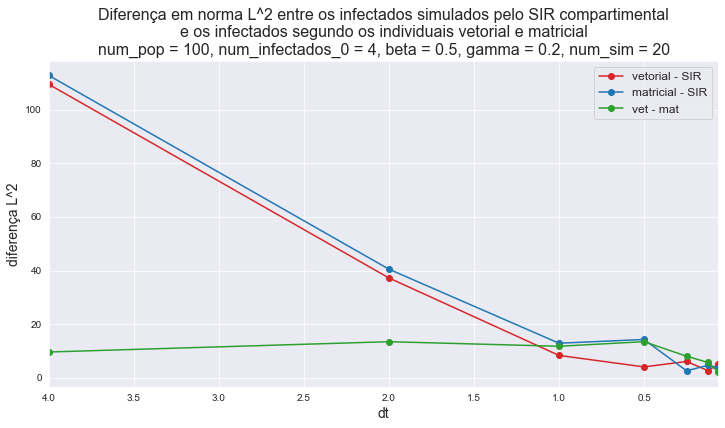

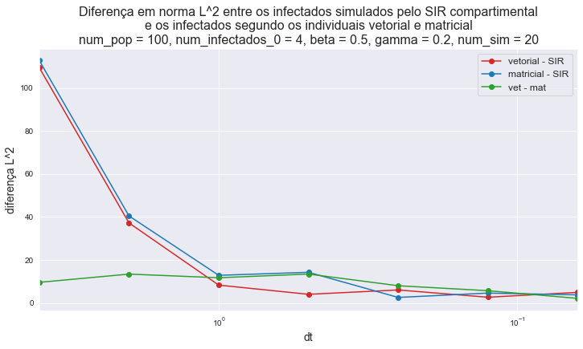

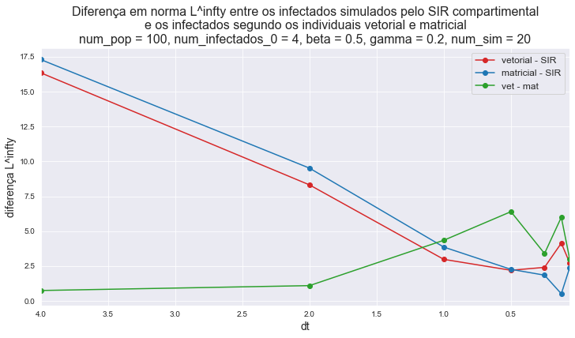

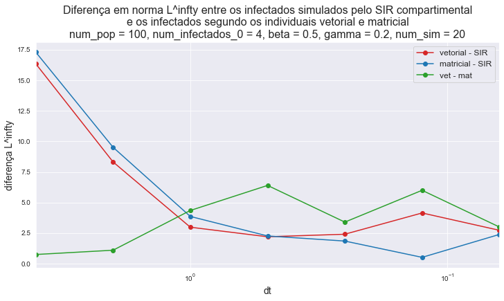

```python
exibe_convergencia(dt_lista, num_pop, num_infectados_0, beta, gamma, num_sim,
                   l_2_comp, l_2_comp_mat, l_2_dif, norma = 'L^2', xscale = 'linear')
exibe_convergencia(dt_lista, num_pop, num_infectados_0, beta, gamma, num_sim,
                   l_2_comp, l_2_comp_mat, l_2_dif, norma  = 'L^2', xscale = 'log')
exibe_convergencia(dt_lista, num_pop, num_infectados_0, beta, gamma, num_sim,
                   l_infty_comp, l_infty_comp_mat, l_infty_dif, norma  = 'L^infty', xscale = 'linear')
exibe_convergencia(dt_lista, num_pop, num_infectados_0, beta, gamma, num_sim,
                   l_infty_comp, l_infty_comp_mat, l_infty_dif, norma  = 'L^infty', xscale = 'log')
```

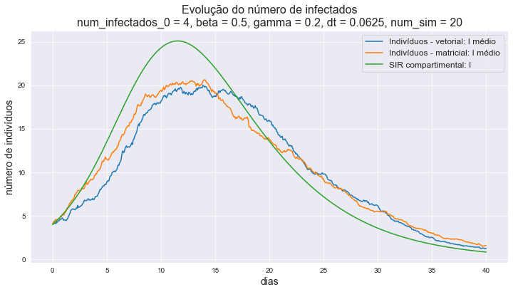

```python
exibe_comparacao(X_comp, X_comp_mat, X_sir, num_infectados_0, beta, gamma, dt, num_sim)
```

## Análise

### EDO determinística

- Considere a seguinte EDO com $\beta$, $N$ constantes e $I=I(t)$:

$$ \frac{\mathrm{d} S}{\mathrm{d} t} = -\frac{\beta}{N} S I. $$

- Solução exata em um intervalo $[t_0, t_0 + \Delta t]$:

$$ S(t) = S(t_0)e^{\displaystyle -\frac{\beta}{N}\int_{t_0}^{t}I(s)\;\mathrm{d}s}. $$

- Diferença em $S(t)$:

$$ \Delta S = S(t_0+\Delta t) - S(t_0) = S(t_0)\left(e^{\displaystyle -\frac{\beta}{N}\int_{t_0}^{t_0+\Delta t}I(s)\;\mathrm{d}s} - 1\right). $$

- Isso nos dá os **novos infectados**:

$$ \Delta I = - \Delta S = S(t_0)\left(1 - e^{\displaystyle -\frac{\beta}{N}\int_{t_0}^{t_0+\Delta t}I(s)\;\mathrm{d}s}\right). \qquad \qquad (1) $$

### Aproximação da EDO determinística

Podemos considerar quatro aproximações distintas para a solução exata. A primeira é a clássica aproximação de Euler. A terceira está diretamente ligada ao **modelo de indivíduos** (versão vetorial).

- Aproximação de **Euler:**

$$ S(t_0+\Delta t) = S(t_0) - \frac{\beta}{N}I(t_0)S(t_0)\Delta t + \mathcal{O}(\Delta t^2), $$

o que nos leva a

$$ \Delta I = S(t_0)\frac{\beta}{N}I(t_0) \Delta + \mathcal{O}(\Delta t^2). $$

- Aproximação **expandindo a exponencial**

$$ e^{\displaystyle -\frac{\beta}{N}\int_{t_0}^{t_0+\Delta t}I(s)\;\mathrm{d}s} = 1 - \frac{\beta}{N}\int_{t_0}^{t_0+\Delta t}I(s)\;\mathrm{d}s + \mathcal{O}(\Delta t^2), $$

o que nos leva a

$$ \Delta I = S(t_0)\frac{\beta}{N}\int_{t_0}^{t_0+\Delta t}I(s)\;\mathrm{d}s + \mathcal{O}(\Delta t^2). $$

- Aproximação **expandindo a integral** dentro da exponencial. Como

$$ \int_{t_0}^{t_0+\Delta t}I(s)\;\mathrm{d}s = I(t_0)\Delta t + \int_{t_0}^{t_0+\Delta t}(I(s)-I(t_0))\;\mathrm{d}s = I(t_0)\Delta t + \mathcal{O}(\Delta t^2), $$

temos

$$ \Delta I = S(t_0)\left(1 - e^{\displaystyle -\frac{\beta}{N} I(t_0) \Delta t} \right) + \mathcal{O}(\Delta t^2). $$

- Aproximação **expandindo a exponencial e a integral**:

$$ \Delta I = S(t_0)\frac{\beta}{N}I(t_0)\Delta t + \mathcal{o}(\Delta t), $$

### Aproximação estocástica pelo método matricial

- No **método matricial**, a probabilidade de um infectado $k$ contagiar um suscetível $i$, do instante $t_0$ para o $t_0+\Delta t$, é

$$ \left(1 - e^{\displaystyle -\frac{\beta}{N}\Delta t}\right). $$

- A probabilidade de um suscetível $i$ ser infectado pelo conjunto de infectados é

$$ I(t_0)\left(1 - e^{\displaystyle -\frac{\beta}{N}\Delta t}\right). $$

- Juntando todos os suscetíveis, obtemos o **incremento do número de infectados**:

$$ \Delta I = S(t_0)I(t_0)\left(1 - e^{\displaystyle -\frac{\beta}{N}\Delta t}\right). \qquad \qquad \mathrm{(2)} $$

- Aproximando a exponencial:

$$ \Delta I = \frac{\beta}{N}S(t_0)I(t_0)\Delta t + \mathcal{O}(\Delta t^2) $$

- Mas é importante ressaltar que, pela natureza estocástica do modelo, a relação (2) acima não é tão direta assim, valendo em um sentido "médio".

### Aproximação estocástica pelo método vetorial

- No **método vetorial**, calculamos a **força de infecção** agindo em um suscetível $i$ como sendo

$$ \lambda_i = \frac{\beta}{N}I(t_0). $$

- A probabilidade de um indivíduo suscetível $i$ ser infectado pelo conjunto de infectados é

$$ 1 - e^{-\lambda_i \Delta t} = 1 - e^{ \displaystyle - \frac{\beta}{N}I(t_0)\Delta t}. $$

- Juntando todos os suscetíveis, obtemos o **incremento do número de infectados:**

$$ \Delta I = S(t_0)\left(1 - e^{ \displaystyle - \frac{\beta}{N}I(t_0)\Delta t}\right). \qquad \qquad \mathrm{(1)}. \qquad \qquad \mathrm{(3)} $$

- Expandindo:

$$ \Delta I = \frac{\beta}{N}S(t_0)I(t_0)\Delta t + \mathcal{O}(\Delta t^2). $$

- Novamente, devido à natureza estocástica do modelo, a relação (3) acima não é tão direta assim, valendo em um sentido "médio".

### Diferença entre os métodos

- Temos

$$ \Delta I_{\textrm{matricial}} = S(t_0)I(t_0)\left(1 - e^{\displaystyle -\frac{\beta}{N}\Delta t}\right) \qquad \Delta I_{\textrm{vetorial}} = S(t_0)\left(1 - e^{ \displaystyle - \frac{\beta}{N}I(t_0)\Delta t}\right). $$

## Trabalhos

### Parte 1

Considere o seguinte sistema simplificado de equações diferenciais, em um intervalo de tempo $[t_0, T]$:

$$ \begin{cases} S' = - \frac{\beta}{N}S I, \\ I' = \frac{\beta}{N} S I, \end{cases} $$

onde $\beta>0$, $N\in \mathbb{R}$ são constantes. Suponha que as condições iniciais $I(t_0)$ e $S(t_0)$ satisfaçam

$$ S(t_0) \geq 0, \;I(t_0) \geq 0, \;S(t_0) + I(t_0) = N. $$

### Parte 2

Considere, agora, uma família de aproximações $(I^{h}, S^{h})_h$ dadas recursivamente por

$$ \begin{cases} S^h_l = N - I^h_l, \\ I^h_{l+1} = I^h_l + S^h_l\left(1 - e^{ \displaystyle - \frac{\beta}{N}I_lh}\right), \quad l = 0, \ldots, L-1, \end{cases} $$

onde $L\in \mathbb{N}$ e com $h = h_L = T/L$ fazendo o papel de $\Delta t$.

Observe que, pelas relações $S(t) = N - I(t)$ e $S^h_l = N - I^h_l$, basta estabelecermos a convergência de $I^h$ para $I$, nos pontos $t_l = t_0 + lh$, $l=0, \ldots, L$ de cada malha.

Denotamos por $\Lambda^h$ a família de operadores

$$ \Lambda_h(I) = \frac{S}{h}\left(1 - e^{ \displaystyle - \frac{\beta}{N}Ih}\right), $$

para $I\in \mathbb{R}$, com $S=N-I$, de forma que

$$ I^h_{l+1} = I^h_l + h \Lambda_h(I^h_l), \qquad l = 0, \ldots, L-1. $$

Por fim, seja $\tau_l^h$ o **erro de truncamento local** dado por

$$ \tau_{l+1}^h = \frac{I(t_{l+1}) - I(t_l)}{h} - \Lambda_h(I(t_l)). $$

1. Mostre que $$ 0 \leq \Lambda_h(I)\leq \beta I, \qquad \forall I\geq 0, $$ e obtenha a seguinte **limitação uniforme** para as soluções: $$ 0 \leq I_l^h \leq I_0^h e^{\beta lh}, \qquad \forall l=0, \ldots, L. $$
2. Mostre que, para quaisquer $I_a, I_b\geq 0$, $$ |\Lambda_h(I_a) - \Lambda_h(I_b)| \leq 2\beta |I_a - I_b| $$ e obtenha a **estabilidade** do método: $$ |I^h_{a, l} - I^h_{b, l}| \leq |I_{a,0}-I_{b,0}|e^{2\beta lh}, \qquad \forall l=0, \ldots, L. $$
3. Mostre que o erro de truncamento satisfaz $$ |\tau_{l+1}^h| \leq \beta \max_{s\in [0,T]}|I'(s)| \frac{h}{2}. $$ Conclua, com isso, que a aproximação é **consistente** com a equação diferencial e é de **ordem 1**.
4. Com base nas estimativas de estabilidade e consistência acima, mostre a **convergência** da aproximação, no intervalo $[0,T]$, quando $L \rightarrow \infty$. Mais precisamente, mostre que $$ |I(t_l) - I_l^h| \leq \max_{s\in [0,T]}|I'(s)|\left(e^{2\beta lh} - 1\right)\frac{h}{4} + e^{2\beta l h}|I(t_0) - I_0^h|, $$ de modo que $\max_{l=0,\ldots,L} |I(t_l)- I_l^h| \rightarrow 0$, quando $L\rightarrow \infty$.
5. Numa situação inicial de epidemia, temos $I'(0)> 0$. Supondo $I_0^h=I(0)$, mostre que $$ I(h)> I_1^h. $$

### Parte 3

Considere, agora, a família de operadores

$$ \tilde\Lambda_h(I) = \frac{SI}{h}\left(1 - e^{ \displaystyle - \frac{\beta}{N}h}\right) $$

e a aproximação associada

$$ \tilde I^h_{l+1} = \tilde I^h_l + h \Lambda_h(\tilde I^h_l), \qquad l = 0, \ldots, L-1. $$

1. Mostre que $$ \tilde\Lambda_h(I_0) < \Lambda_h(I_0), \quad \textrm{para } 0 \leq I_0 < 1 $$ e que $$ \tilde\Lambda_h(I_0) > \Lambda_h(I_0), \quad \textrm{para } I_0 > 1. $$